# Lecture : Probabilities continued and Frequency Distributions (POLS 3316 - Statistics for Political Scientists)

Tom Hanna

### Recap

- P(A) = $\frac{Favorable Outcomes}{All Possible Outcomes}$ (where “favorable” means outcomes where A occurs)
- P(A) is the proportion we expect if we repeat the process a large number of times
- Proportion of *elements* or *subsets* to the *sample space*
- Important terms: *union*, *intersection*, *mutually exclusive*, *empty set*, *complement*, *event*
- Probability rules: 0 to 1. P(Something) = 1.

$$\\[4in]$$

### Non-mutually exclusive sets

- The probability for the union of mutually exclusive sets was the sum of their probabilities: P(A $\cup$ B) = P(A) + P(B)
- With non-mutually exclusive sets this results in double counting. It could lead to P > 1

Example:

- S = {A,B,C,D,E,F,G,H} (8 possibilities)
- B = {A,B,C,D,E} (5 favorable)
- A = {D,E,F,G,H} (5 favorable)
- P(A) = 5/8 and P(B) = 5/8
- P(A $\cup$ B) = 10/8 violates the rule P = 0 to 1
- {D,E} got counted twice
- {D,E} is A $\cap$ B
- So for non-exclusive pairs, our formula is:

**P(A $\cup$ B) = P(A) + P(B) - P(A $\cap$ B)**

*Note that this actually works for mutually exclusive sets to because for mutually exclusive sets, the intersection is the empty set and has P = 0*

$$\\[4in]$$

### Independence

- For now, problems will assume independence unless explicitly specified *
- Non-independent (conditional) events are covered by Bayes Rule
- You don’t have to worry about Bayes Rule for now except to understand that it exists and applies to non-independent events
- Independent events are unrelated
- If learning the probability of one event (A) doesn’t affect the probability of the other event (B), they are independent
- Example: If I draw a number from a hat, then flip a coin the outcome of the draw doesn’t affect the outcome of the coin flip.
- P(A $\cap$ B) = P(A)P(B) for independent events
- The probability rules for non-independent events, called *conditional probability*, are different
- Question: What if on a short answer test question, I ask: “Event A and Event B are not independent. How would you determine the conditional probability of event A given event B?” What would you answer?

$$\\[4in]$$

Answer: I would apply Bayes Rule. **OR** I would construct a sample space and determine the probabilities with set theory. (This is what Bayes actually does.)

$$\\[4in]$$

### Data Assumptions: Random, Independent, and Identically Distributed

- Randomness and independence matter as assumptions about data
- Specifically, these are assumptions about the *Data Generating Process* of DGP
- Purpose: analyzing data for causal inference (to begin to make statements about cause and effect - inferring causes)
- The source of the data matters - the DGP matters
- Previously stated: Data comes from a random world
- So the DGP is random
- Events in the data are *independent and identically distributed* - the IID assumption
- Independence is statistical independence - the outcome of one event does not affect our belief about the probability of another event
- Identically distributed: drawn from the same *probability distribution*

$$\\[4in]$$

### Introduction to distributions

- R has functions for at least 20 distributions
- The most important is the *normal distribution*
- This is because of the *central limit theorem*
- We will look at these in the most detail: *normal*, *binomial*, *uniform*

$$\\[4in]$$

#### Uniform distribution

**All outcomes are equally likely**

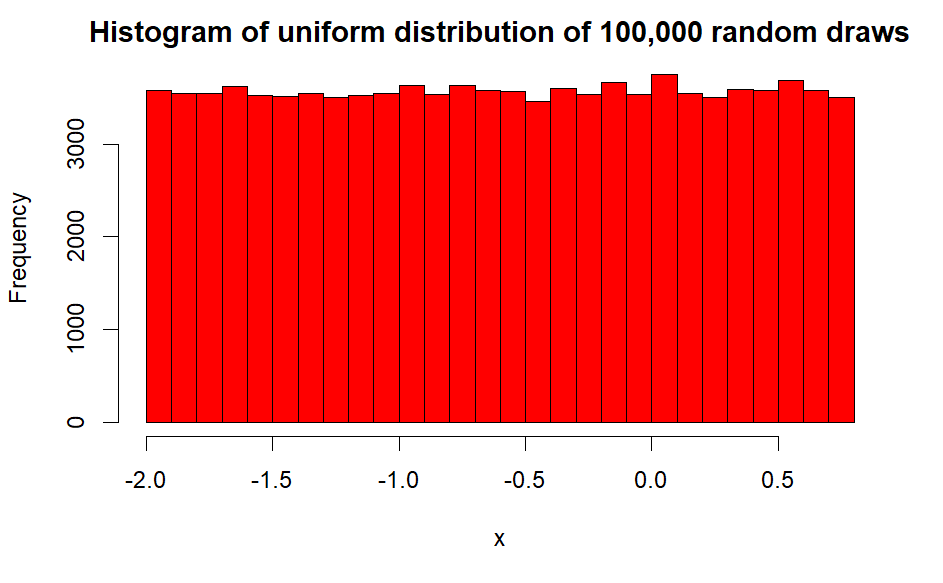

```r
rand.unif <- runif(100000, min = -2, max = 0.8)
hist(rand.unif, breaks = 20, freq = TRUE, main = "Histogram of uniform distribution of 100,000 random draws", xlab = 'x', col = "red")
```

$$\\[4in]$$

#### Normal Distribution

- *symmetrical around its mean with most values near the central peak*
- width is a function of the standard deviation
- Other names: Gaussian distribution, bell curve

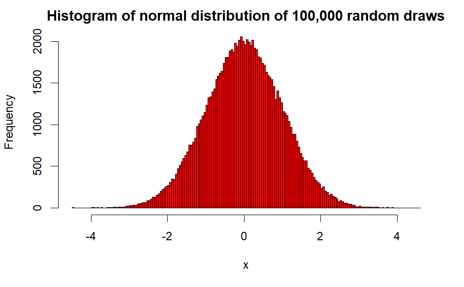

```r
rand.norm<- rnorm(100000)
hist(rand.norm, breaks = 200, freq = TRUE, main = "Histogram of normal distribution of 100,000 random draws", xlab = 'x', col = "red")
```

$$\\[4in]$$

#### Binomial Distribution

- success or failure
- yes no

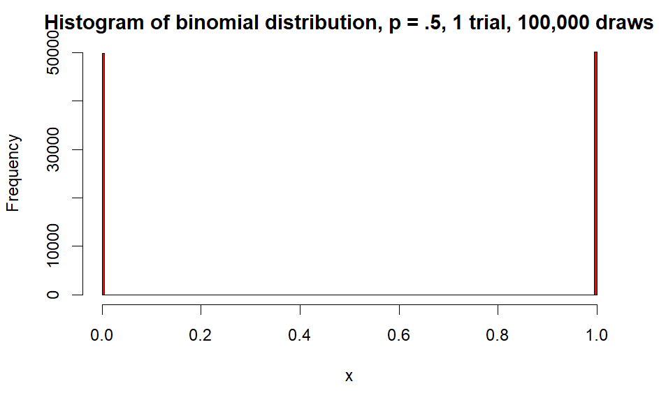

```r
rand.binom<- rbinom(100000,1,.5)
hist(rand.binom, breaks = 200, freq = TRUE, main = "Histogram of binomial distribution, p = .5, 1 trial, 100,000 draws", xlab = 'x', col = "red")
```

$$\\[4in]$$

## Preview of the Central Limit Theorem

What happens if we do the same thing above but do it 1,000 times and plot the counts?

```r
rand.binom<- rbinom(100000,1,.5)
hist(rand.binom, breaks = 200, freq = TRUE, main = "Histogram of binomial distribution, p = .5, 1 trial, 100,000 draws", xlab = 'x', col = "red")

rand.binom2<- rbinom(100000,1000,.5)
hist(rand.binom2, breaks = 200, freq = TRUE, main = "Histogram of binomial distribution, p = .5, 1000 trials, 100,000 draws", xlab = 'x', col = "red")
```

[output not shown]